# House Pricing Prediction

This challenge is adapted from the well-known '*Zillow's Home Value Prediction*' competition on Kaggle. In particular, given a dataset containing descriptions of homes on the US property market, your task is to make predictions on the selling price of as-yet unlisted properties. Developing a model which accurately fits the available training data while also generalising to unseen data-points is a multi-faceted challenge that involves a mixture of data exploration, pre-processing, model selection, and performance evaluation.

**IMPORTANT**: please refer to the AML course guidelines concerning grading rules. Pay especially attention to the **presentation quality** item, which boils down to: don't dump a zillion of lines of code and plots in this notebook. Produce a concise summary of your findings: this notebook can exist in two versions, a "scratch" version that you will use to work and debug, a "presentation" version that you will submit. The "presentation" notebook should go to the point, and convay the main findings of your work.

## Overview

Beyond simply producing a well-performing model for making predictions, in this challenge we would like you to start developing your skills as a machine learning scientist. In this regard, your notebook should be structured in such a way as to explore the following tasks that are expected to be carried out whenever undertaking such a project. The description below each aspect should serve as a guide for your work, but you are strongly encouraged to also explore alternative options and directions. Thinking outside the box will always be rewarded in these challenges.

### 1. Data preparation:

*Data exploration*: The first broad component of your work should enable you to familiarise yourselves with the given data, an outline of which is given at the end of this challenge specification. Among others, you can work on:

- Data cleaning, e.g. treatment of categorial variables;
- Data visualisation; Computing descriptive statistics, e.g. correlation.

*Data Pre-processing*: The previous step should give you a better understanding of which pre-processing is required for the data. This may include:

- Normalising and standardising the given data;
- Removing outliers;
- Carrying out feature selection, possibly using metrics derived from information theory;
- Handling missing information in the dataset;
- Augmenting the dataset with external information;
- Combining existing features.

### 2. Model selection

An important part of the work involves the selection of a model that can successfully handle the given data and yield sensible predictions. Instead of focusing exclusively on your final chosen model, it is also important to share your thought process in this notebook by additionally describing alternative candidate models. There is a wealth of models to choose from, such as decision trees, random forests, (Bayesian) neural networks, Gaussian processes, LASSO regression, and so on.

Irrespective of your choice, it is highly likely that your model will have one or more parameters that require tuning. There are several techniques for carrying out such a procedure, such as cross-validation.

### 3. Performance Evaluation

The evaluation method for this challenge is the root mean squared error between the logarithm of the predicted value and the logarithm of the observed sales price. Taking logs ensures that errors in predicting expensive houses and cheap houses will have a similar impact on the overall result.

## Dataset Description

#### Files

You will be working on two data files, which will be available in `/mnt/datasets/house/`:

- train.csv - The training dataset;
- test.csv - The test dataset;
- data_description.txt - Full description of each column.

#### Attributes

A brief outline of the available attributes is given below:

- *SalePrice*: The property's sale price in dollars. This is the target variable that your model is intended to predict;
- *MSSubClass*: The building class;
- *MSZoning*: The general zoning classification;
- *LotFrontage*: Linear feet of street connected to property;
- *LotArea*: Lot size in square feet;
- *Street*: Type of road access;
- *Alley*: Type of alley access;
- *LotShape*: General shape of property;
- *LandContour*: Flatness of the property;
- *Utilities*: Type of utilities available;
- *LotConfig*: Lot configuration;
- *LandSlope*: Slope of property;
- *Neighborhood*: Physical locations within Ames city limits;
- *Condition1*: Proximity to main road or railroad;
- *Condition2*: Proximity to main road or railroad (if a second is present);
- *BldgType*: Type of dwelling;
- *HouseStyle*: Style of dwelling;
- *OverallQual*: Overall material and finish quality;
- *OverallCond*: Overall condition rating;
- *YearBuilt*: Original construction date;
- *YearRemodAdd*: Remodel date;
- *RoofStyle*: Type of roof;
- *RoofMatl*: Roof material;
- *Exterior1st*: Exterior covering on house;
- *Exterior2nd*: Exterior covering on house (if more than one material);
- *MasVnrType*: Masonry veneer type;
- *MasVnrArea*: Masonry veneer area in square feet;
- *ExterQualv*: Exterior material quality;
- *ExterCond*: Present condition of the material on the exterior;
- *Foundation*: Type of foundation;
- *BsmtQual*: Height of the basement;
- *BsmtCond*: General condition of the basement;
- *BsmtExposure*: Walkout or garden level basement walls;
- *BsmtFinType1*: Quality of basement finished area;
- *BsmtFinSF1*: Type 1 finished square feet;
- *BsmtFinType2*: Quality of second finished area (if present);
- *BsmtFinSF2*: Type 2 finished square feet;
- *BsmtUnfSF*: Unfinished square feet of basement area;
- *TotalBsmtSF*: Total square feet of basement area;
- *Heating*: Type of heating;
- *HeatingQC*: Heating quality and condition;
- *CentralAir*: Central air conditioning;
- *Electrical*: Electrical system;
- *1stFlrSF*: First Floor square feet;
- *2ndFlrSF*: Second floor square feet;
- *LowQualFinSF*: Low quality finished square feet (all floors);
- *GrLivArea*: Above grade (ground) living area square feet;
- *BsmtFullBath*: Basement full bathrooms;
- *BsmtHalfBath*: Basement half bathrooms;
- *FullBath*: Full bathrooms above grade;
- *HalfBath*: Half baths above grade;
- *BedroomAbvGr*: Number of bedrooms above basement level;
- *KitchenAbvGr*: Number of kitchens;
- *KitchenQual*: Kitchen quality;
- *TotRmsAbvGrd*: Total rooms above grade (does not include bathrooms);
- *Functional*: Home functionality rating;
- *Fireplaces*: Number of fireplaces;
- *FireplaceQu*: Fireplace quality;
- *GarageType*: Garage location;
- *GarageYrBlt*: Year garage was built;
- *GarageFinish*: Interior finish of the garage;
- *GarageCars*: Size of garage in car capacity;
- *GarageArea*: Size of garage in square feet;
- *GarageQual*: Garage quality;
- *GarageCond*: Garage condition;
- *PavedDrive*: Paved driveway;
- *WoodDeckSF*: Wood deck area in square feet;
- *OpenPorchSF*: Open porch area in square feet;
- *EnclosedPorch*: Enclosed porch area in square feet;
- *3SsnPorch*: Three season porch area in square feet;
- *ScreenPorch*: Screen porch area in square feet;
- *PoolArea*: Pool area in square feet;
- *PoolQC*: Pool quality;
- *Fence*: Fence quality;
- *MiscFeature*: Miscellaneous feature not covered in other categories;
- *MiscVal*: Value (in dollars) of miscellaneous feature;
- *MoSold*: Month sold;
- *YrSold*: Year sold;
- *SaleType*: Type of sale;
- *SaleCondition*: Condition of sale.

## Code part

### Imports

```python
#Libraries
import numpy as np # linear algebra
import pandas as pd # data processing, CSV file I/O (e.g. pd.read_csv)
import seaborn as sns
import matplotlib.pyplot as plt
from sklearn.compose import ColumnTransformer
from sklearn.pipeline import Pipeline
from sklearn.impute import SimpleImputer
from sklearn.preprocessing import OneHotEncoder, OrdinalEncoder
from sklearn.ensemble import RandomForestRegressor
from sklearn.ensemble import GradientBoostingRegressor
from sklearn.metrics import mean_absolute_error
from sklearn.metrics import roc_curve, auc
from sklearn.model_selection import cross_val_score
from sklearn.model_selection import cross_validate
from sklearn.model_selection import GridSearchCV
from sklearn.svm import SVR
from sklearn.linear_model import LogisticRegression
from sklearn import preprocessing



test = pd.read_csv("test.csv")
train = pd.read_csv("train.csv")
print("Import complete")
```

```
Import complete
```

### 1. Data preparation

#### Correlation

```
--- features with a correlation with SalePrice > 0.6:
['OverallQual' 'ExterQual' 'TotalBsmtSF' '1stFlrSF' 'GrLivArea'
 'GarageCars' 'GarageArea']
```

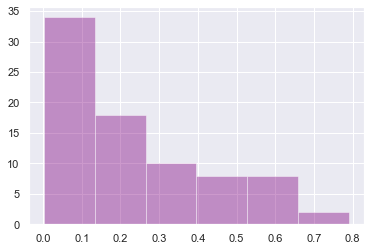

```python
train_cat = train.copy()
str_features = [col for col in train.columns if train[col].dtype == 'object']
for feature in str_features:
    train_cat[feature]=train_cat[feature].astype('category').cat.codes
correlations = train_cat.corr()["SalePrice"].drop(["SalePrice"]).abs()
best_features = correlations.index.to_numpy()[np.array(correlations.values) > 0.6]
sns.set(style="darkgrid")
sns.distplot(correlations.values, kde=False, color="purple")
print("--- features with a correlation with SalePrice > 0.6:")
print(best_features)
```

Why relevant? (eg Index, PoolQC...)

```python
selected_features = correlations.index.to_numpy()[np.array(correlations.values) > 0.1]
print("Number of selected features with a threshold of 0.1:", selected_features.shape[0])
selected_features
```

```
Number of selected features with a threshold of 0.1: 53
```

```
array(['MSZoning', 'LotFrontage', 'LotArea', 'LotShape', 'Neighborhood',
       'HouseStyle', 'OverallQual', 'YearBuilt', 'YearRemodAdd',
       'RoofStyle', 'RoofMatl', 'MasVnrArea', 'ExterQual', 'ExterCond',
       'Foundation', 'BsmtQual', 'BsmtCond', 'BsmtExposure', 'BsmtFinSF1',
       'BsmtFinType2', 'BsmtUnfSF', 'TotalBsmtSF', 'HeatingQC',
       'CentralAir', 'Electrical', '1stFlrSF', '2ndFlrSF', 'GrLivArea',
       'BsmtFullBath', 'FullBath', 'HalfBath', 'BedroomAbvGr',
       'KitchenAbvGr', 'KitchenQual', 'TotRmsAbvGrd', 'Functional',
       'Fireplaces', 'FireplaceQu', 'GarageType', 'GarageYrBlt',
       'GarageFinish', 'GarageCars', 'GarageArea', 'GarageQual',
       'GarageCond', 'PavedDrive', 'WoodDeckSF', 'OpenPorchSF',
       'EnclosedPorch', 'ScreenPorch', 'PoolArea', 'Fence',
       'SaleCondition'], dtype=object)
```

#### Missing value handling

```python
nan_count = train[selected_features].isna().sum()
print("NaN values count")
print(nan_count[nan_count.index[nan_count.to_numpy().nonzero()]])
```

```
NaN values count
LotFrontage     210
MasVnrArea        6
BsmtQual         32
BsmtCond         32
BsmtExposure     33
BsmtFinType2     33
FireplaceQu     564
GarageType       67
GarageYrBlt      67
GarageFinish     67
GarageQual       67
GarageCond       67
Fence           973
dtype: int64
```

The missing values are due to 2 things:

- Description of a missing thing. We just need to create a new category "None" to indicate there is nothing.
- Measure of a missing thing. We can simply replace the NaN values by zeros since their absence correpond to 0 length/area.

| Feature | Solution |
| --- | --- |
| LotFrontage | NaN replaced by Zeros |
| MasVnrArea | NaN replaced by Zero |
| FireplaceQu | New category "None" |
| Fence | New category "None" |
| Bsmt* | New category "None" |
| Garage* | New category "None" |

* Contains all subcategories starting with this name

```python
# Filling missing values
train["MasVnrArea"].astype('float64')
test["MasVnrArea"].astype('float64')
train["MasVnrArea"] = train["MasVnrArea"].fillna(0.)
test["MasVnrArea"] = test["MasVnrArea"].fillna(0.)
train["LotFrontage"] = train["LotFrontage"].fillna(0.)
test["LotFrontage"] = test["LotFrontage"].fillna(0.)
NaN_features = ["FireplaceQu", "Fence", "BsmtExposure", "BsmtQual", "BsmtCond", "BsmtFinType2",
               "GarageType", "GarageYrBlt", "GarageFinish", "GarageQual", "GarageCond"]
for feature in NaN_features:
    train[feature] = train[feature].fillna("None")
    test[feature] = test[feature].fillna("None")
```

```python
train_clean = train[selected_features]
test_clean = test[selected_features]
```

```python
# Let's focus on numerical features first

numerical_cols = [col for col in train_clean.columns
                  if train_clean[col].dtype == 'int64'
                  or train_clean[col].dtype == 'float64']
print("Number of columns that are numerical: " + str(len(numerical_cols)))
print()
categorical_cols = [col for col in train_clean.columns
                    if train_clean[col].dtype == 'object']
print("Number of columns that are categorical: " + str(len(categorical_cols)))
```

```
Number of columns that are numerical: 26

Number of columns that are categorical: 27
```

### feature grouping

The only relevant grouping we found was to add the number of half/full bathrooms with respect to their location (basement or above grade).

```python
train_aug = train_clean
train_aug.loc[:, "TotFullBath"] = train.loc[:, "FullBath"] + train.loc[:, "BsmtFullBath"]
train_aug.loc[:, "TotHalfBath"] = train.loc[:, "HalfBath"] + train.loc[:, "BsmtHalfBath"]

test_aug = test_clean
test_aug.loc[:, "TotFullBath"] = test.loc[:, "FullBath"] + test.loc[:, "BsmtFullBath"]
test_aug.loc[:, "TotHalfBath"] = test.loc[:, "HalfBath"] + test.loc[:, "BsmtHalfBath"]
```

### Data Normalization

```python
unique = train_aug[numerical_cols].nunique()
continous_numerical_cols = unique.index.to_numpy()[unique.to_numpy() > 50]
discrete_numerical_cols = unique.index.to_numpy()[unique.to_numpy() < 50]
```

```python
# normalization of the numerical columns

x = train_aug[continous_numerical_cols].values #returns a numpy array
min_max_scaler = preprocessing.MinMaxScaler()
x_scaled = min_max_scaler.fit_transform(x)
train_normalized_numerical_cols = pd.DataFrame(x_scaled)


x_test = test_aug[continous_numerical_cols].values #returns a numpy array
min_max_scaler = preprocessing.MinMaxScaler()
x_test_scaled = min_max_scaler.fit_transform(x_test)
test_normalized_numerical_cols = pd.DataFrame(x_test_scaled)
```

```python
# categorical_cols = np.array(categorical_cols)
# categorical_cols = np.concatenate((categorical_cols, discrete_numerical_cols))
```

```python
trainy = train.loc[:,['SalePrice']]
trainX = train_aug[categorical_cols].astype(str)
trainX[continous_numerical_cols] = train_normalized_numerical_cols #normalization
testy = test.loc[:,['SalePrice']]
testX = test_aug[categorical_cols].astype(str)
testX[continous_numerical_cols] = test_normalized_numerical_cols #normalization

trainX.head()
```

|  | MSZoning | LotShape | Neighborhood | HouseStyle | RoofStyle | RoofMatl | ExterQual | ExterCond | Foundation | BsmtQual | ... | BsmtUnfSF | TotalBsmtSF | 1stFlrSF | 2ndFlrSF | GrLivArea | GarageArea | WoodDeckSF | OpenPorchSF | EnclosedPorch | ScreenPorch |
| --- | --- | --- | --- | --- | --- | --- | --- | --- | --- | --- | --- | --- | --- | --- | --- | --- | --- | --- | --- | --- | --- |
| 0 | RL | Reg | CollgCr | 2Story | Gable | CompShg | Gd | TA | PConc | Gd | ... | 0.064212 | 0.266999 | 0.180373 | 0.413559 | 0.316905 | 0.394245 | 0.000000 | 0.116635 | 0.000000 | 0.0 |
| 1 | RL | Reg | Veenker | 1Story | Gable | CompShg | TA | TA | CBlock | Gd | ... | 0.121575 | 0.393637 | 0.320663 | 0.000000 | 0.213726 | 0.330935 | 0.347725 | 0.000000 | 0.000000 | 0.0 |
| 2 | RL | IR1 | CollgCr | 2Story | Gable | CompShg | Gd | TA | PConc | Gd | ... | 0.185788 | 0.286962 | 0.202488 | 0.419370 | 0.334408 | 0.437410 | 0.000000 | 0.080306 | 0.000000 | 0.0 |
| 3 | RL | IR1 | Crawfor | 2Story | Gable | CompShg | TA | TA | BrkTil | TA | ... | 0.231164 | 0.235808 | 0.216655 | 0.366102 | 0.318517 | 0.461871 | 0.000000 | 0.066922 | 0.492754 | 0.0 |
| 4 | RL | IR1 | NoRidge | 2Story | Gable | CompShg | Gd | TA | PConc | Gd | ... | 0.209760 | 0.357143 | 0.280235 | 0.509927 | 0.429295 | 0.601439 | 0.224037 | 0.160612 | 0.000000 | 0.0 |

5 rows × 43 columns

```python
#We will use imputers, as they are convenient for data preprocessing
categorical_transformer = Pipeline(steps=[
    ('onehot', OrdinalEncoder())
])

# We create the preprocessor. It will be used to preprocess the data  when we fit the model to the training set.
preprocessor = ColumnTransformer(
    transformers=[
        ('cat', categorical_transformer, categorical_cols)
    ])
```

```python
encoder = OrdinalEncoder()
tot = pd.concat([trainX, testX])
encoder.fit(tot)
```

```
OrdinalEncoder(categories='auto', dtype=<class 'numpy.float64'>)
```

### 2. Model selection

#### random forest regressor

```python
model = RandomForestRegressor(verbose=0, n_estimators=10)

# With cross walidation scores, we have a better estimation of the efficiency of the model
# Multiply by -1 since sklearn calculates *negative* MAE
scores = -1 * cross_val_score(model, encoder.transform(trainX), trainy.values.ravel(),
                              cv=5,
                              scoring='neg_mean_squared_error',
                              n_jobs=-1)
print("Average RMSE score (across experiments): ", np.sqrt(scores.mean()))
```

```
Average RMSE score (across experiments):  33649.18188860875
```

#### gradient boosting regressor

```python
model = GradientBoostingRegressor(verbose = 0)
#This is the whole pipeline (Preprocessor + model) to apply on the data
# pipeline = Pipeline(steps=[('preprocessor', preprocessor),
#                               ('model', model)
#                              ])

#With cross walidation scores, we have a better estimation of the efficiency of the model
# Multiply by -1 since sklearn calculates *negative* MAE
scores = -1 * cross_val_score(model, encoder.transform(trainX), trainy.values.ravel(),
                            cv=5,
                            scoring='neg_mean_squared_error',
                            n_jobs=-1)
print("Average RMSE score (across experiments): ", np.sqrt(scores.mean()))
```

```
Average RMSE score (across experiments):  31188.798396299935
```

#### SVM classifier

```python
model = SVR(gamma='auto')
#This is the whole pipeline (Preprocessor + model) to apply on the data
# pipeline = Pipeline(steps=[('preprocessor', preprocessor),
#                               ('model', model)
#                              ])

#With cross walidation scores, we have a better estimation of the efficiency of the model
# Multiply by -1 since sklearn calculates *negative* MAE
scores = -1 * cross_val_score(model, encoder.transform(trainX), trainy.values.ravel(),
                              cv=5,
                              scoring='neg_mean_squared_error',
                              n_jobs=-1)
print("Average RMSE score (across experiments): ", np.sqrt(scores.mean()))
```

```
Average RMSE score (across experiments):  83020.66873031271
```

#### Logistic regression

```python
model = LogisticRegression(max_iter=200)
#This is the whole pipeline (Preprocessor + model) to apply on the data
# pipeline = Pipeline(steps=[('preprocessor', preprocessor),
#                               ('model', model)
#                              ])

#With cross walidation scores, we have a better estimation of the efficiency of the model
# Multiply by -1 since sklearn calculates *negative* MAE
scores = -1 * cross_val_score(model, encoder.transform(trainX), trainy.values.ravel(),
                              cv=5,
                              scoring='neg_mean_squared_error',
                              n_jobs=-1)
print("Average RMSE score (across experiments): ", np.sqrt(scores.mean()))
```

```
Average RMSE score (across experiments):  63818.66108371732
```

[output not shown]

Even without hyperparameter tuning, we can already see that some models are more adapted than others. In fact, as we have a lot of categorical variables, we expected tree based models to give quite good results on this dataset. This was confirmed by the results. In fact, many other models are available, and knowing which one, with which parameter setting, is a tricky process. But in this notebook, we will continue with the gradient boosting regressor model (a tree based model using gradient boosting, which therefore allows better results than Random Forests)

## Hyperparameter tuning

Theory about gradient boosting:

Boosting is a method of converting weak learners into a strong learner ensemble. In boosting, each new tree is a fit on a modified version of the original data set.

After evaluating the first tree, we increase the weights of those observations that are difficult to classify and lower the weights for those that are easy to classify.

```python
model = GradientBoostingRegressor(verbose = 0)
#This is the whole pipeline (Preprocessor + model) to apply on the data

parameters = {
    "learning_rate": [0.1, 0.4, 0.8],
    "n_estimators":[20], # There is often overfitting problems with gradient boosting estimators
    "min_samples_split": np.linspace(0.01, 0.09, 3),
    "min_samples_leaf": np.linspace(0.05, 0.2, 3),
    "max_depth":[3, 4, 5],
    "max_features":["log2", "sqrt"],
    "criterion": ["friedman_mse",  "mae"],
    "subsample":[0.95, 0.99]
    }

clf = GridSearchCV(model, parameters, verbose=1, cv=5, n_jobs=-1)
trainy.values.ravel()
clf.fit(encoder.transform(trainX), trainy.values.ravel())
print(clf.score(encoder.transform(trainX), trainy.values.ravel()))
print(clf.best_params_)
```

```
Fitting 5 folds for each of 648 candidates, totalling 3240 fits
```

```
[Parallel(n_jobs=-1)]: Using backend LokyBackend with 12 concurrent workers.
[Parallel(n_jobs=-1)]: Done  44 tasks      | elapsed:    0.3s
[Parallel(n_jobs=-1)]: Done 1544 tasks      | elapsed:    4.2s
[Parallel(n_jobs=-1)]: Done 2172 tasks      | elapsed:   24.0s
[Parallel(n_jobs=-1)]: Done 2522 tasks      | elapsed:   37.6s
[Parallel(n_jobs=-1)]: Done 2972 tasks      | elapsed:   55.0s
```

```
0.8559138908649218
{'criterion': 'friedman_mse', 'learning_rate': 0.4, 'max_depth': 3, 'max_features': 'sqrt', 'min_samples_leaf': 0.05, 'min_samples_split': 0.01, 'n_estimators': 20, 'subsample': 0.99}
```

```
[Parallel(n_jobs=-1)]: Done 3240 out of 3240 | elapsed:  1.1min finished
```

```python
#we could set subsample lower, to reduce overfitting
bestModel = GradientBoostingRegressor(verbose=0,
                                      criterion='friedman_mse',
                                      learning_rate=0.4,
                                      max_depth=5,
                                      max_features='sqrt',
                                      min_samples_leaf=0.05,
                                      min_samples_split=0.01,
                                      n_estimators=100,
                                      subsample=0.99)
#This is the whole pipeline (Preprocessor + model) to apply on the data

bestModel.fit(encoder.transform(trainX), trainy.values.ravel())
```

```
GradientBoostingRegressor(alpha=0.9, criterion='friedman_mse', init=None,
                          learning_rate=0.4, loss='ls', max_depth=5,
                          max_features='sqrt', max_leaf_nodes=None,
                          min_impurity_decrease=0.0, min_impurity_split=None,
                          min_samples_leaf=0.05, min_samples_split=0.01,
                          min_weight_fraction_leaf=0.0, n_estimators=100,
                          n_iter_no_change=None, presort='auto',
                          random_state=None, subsample=0.99, tol=0.0001,
                          validation_fraction=0.1, verbose=0, warm_start=False)
```

```
(43,)
```

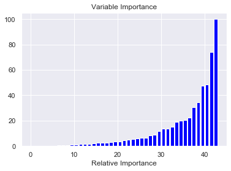

```python
# Plot feature importance
feature_importance = bestModel.feature_importances_
# make importances relative to max importance
feature_importance = 100.0 * (feature_importance / feature_importance.max())
sorted_idx = np.argsort(feature_importance)
print(feature_importance.shape)
pos = np.arange(sorted_idx.shape[0]) + .5
plt.figure()
plt.bar(pos, feature_importance[sorted_idx], align='center', color="blue")
plt.xlabel('Relative Importance')
plt.title('Variable Importance')
plt.show()
```

### 3. Performance Evaluation

The evaluation method for this challenge is the root mean squared error between the logarithm of the predicted value and the logarithm of the observed sales price. Taking logs ensures that errors in predicting expensive houses and cheap houses will have a similar impact on the overall result.

```python
### the result is very good, do not execute this cell
prediction = bestModel.predict(encoder.transform(testX))
def rmse (y, y_hat):
  return np.sqrt(np.mean((y-y_hat)**2))
print("rmse = ", rmse(testy.values.ravel(), prediction))
```

[output not shown]

```python
## just for info
def percentError (y, y_hat):
  return np.mean(np.absolute(y-y_hat)/y)*100

print("mean error on price is ", percentError(testy.values.ravel(), prediction), "%")
print("mean absolute error on price is", np.mean(np.absolute(testy.values.ravel() - prediction)), "$")
print("root mean square error on price is", rmse(testy.values.ravel(), prediction), "$")
```

```
mean error on price is  15.548753654650172 %
mean absolute error on price is 28279.314645017126 $
root mean square error on price is 42716.52764183765 $
```

```
      Iter       Train Loss      OOB Improve   Remaining Time
         1  4911187104.2246  2099209356.4541            0.01s
         2  3802532424.6253  3038702684.9388            0.00s
         3  3559025153.5041   373475706.1779            0.00s
      Iter       Train Loss      OOB Improve   Remaining Time
         1  5193610932.8523   543438605.0660            0.01s
         2  3920069483.6607   818931838.2239            0.00s
         3  3761311600.5830   209539820.2656            0.00s
         4  3408367747.7508   229389282.1967            0.00s
      Iter       Train Loss      OOB Improve   Remaining Time
         1  4512221866.2360   994200155.7611            0.01s
         2  2905960181.1922   -62775503.1286            0.01s
         3  2724498968.9886   -94618272.5780            0.00s
         4  2612657180.0310  -120371852.1163            0.00s
         5  2546454546.7688   156536667.5582            0.00s
```

[output cut: 45 more lines]

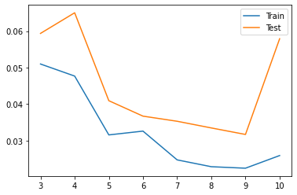

```python
# influence of n_estimators

### results are VERY random !!

x = [3, 4, 5, 6, 7, 8, 9, 10]
ytrain = []
ytest = []

for i in x:
    bestModel = GradientBoostingRegressor(verbose = 1, criterion = 'friedman_mse',learning_rate= 0.6, max_depth= 5, max_features= 'sqrt', min_samples_leaf= 0.1, min_samples_split= 0.01, n_estimators= i, subsample= 0.99)
    bestPipeline = Pipeline(steps=[('preprocessor', preprocessor),
                              ('model', bestModel)
                             ])
    bestPipeline.fit(trainX, trainy.values.ravel())

    prediction = bestPipeline.predict(testX)
    ytest.append(rmse(testy.values.ravel(), prediction))
    prediction = bestPipeline.predict(trainX)
    ytrain.append(rmse(trainy.values.ravel(), prediction))

plt.plot(x, ytrain, label="Train")
plt.plot(x, ytest, label="Test")
plt.legend()
plt.show()
```

```
      Iter       Train Loss      OOB Improve   Remaining Time
         1  5157255572.7538  1276054830.1829            0.03s
         2  3727481570.4625   448822052.6406            0.02s
         3  3377150485.9118   107748037.3512            0.01s
         4  3227637265.3660   327507037.9510            0.01s
         5  3017950558.9769    38160157.8893            0.01s
         6  2796606125.4108  -110552677.4572            0.01s
         7  2667646725.7819   -80414609.3349            0.00s
         8  2630951575.0252    21252004.9345            0.00s
         9  2498411179.2372   272558079.6663            0.00s
      Iter       Train Loss      OOB Improve   Remaining Time
         1  4948928211.2429  2145447220.0889            0.02s
         2  3898859570.2842  2590786157.2214            0.02s
         3  3609668261.2593   590410739.1313            0.01s
         4  3322344452.1661  -510495183.2362            0.01s
```

[output cut: 35 more lines]

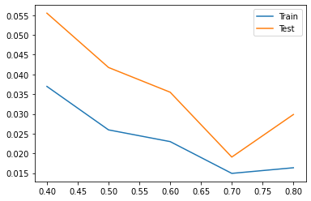

```python
# let's change n_esimators to 9
# influence of learning rate

### results are VERY random !!

x = np.linspace(0.4, 0.8, 5)
ytrain = []
ytest = []

for i in x:
  bestModel = GradientBoostingRegressor(verbose = 1, criterion = 'friedman_mse',learning_rate= i, max_depth= 5, max_features= 'sqrt', min_samples_leaf= 0.1, min_samples_split= 0.01, n_estimators= 9, subsample= 0.99)
  bestPipeline = Pipeline(steps=[('preprocessor', preprocessor),
                              ('model', bestModel)
                             ])
  bestPipeline.fit(trainX, trainy.values.ravel())

  prediction = bestPipeline.predict(testX)
  ytest.append(rmse(testy.values.ravel(), prediction))
  prediction = bestPipeline.predict(trainX)
  ytrain.append(rmse(trainy.values.ravel(), prediction))

plt.plot(x, ytrain, label="Train")
plt.plot(x, ytest, label="Test")
plt.legend()
plt.show()
```

```
      Iter       Train Loss      OOB Improve   Remaining Time
         1  5951409822.7664   742663096.9439            0.02s
         2  4361521378.7743   613738908.7936            0.02s
         3  3997763723.8970   844492182.5074            0.01s
         4  3789674307.4267   320328607.6807            0.01s
         5  3514157839.4507   515952195.7254            0.01s
         6  3194238206.6843   440734574.9974            0.01s
         7  2950207532.8083   -22204537.1462            0.00s
         8  3224349611.4908    32754132.8663            0.00s
         9  3031553954.0532    17678990.5777            0.00s
      Iter       Train Loss      OOB Improve   Remaining Time
         1  5238446865.9758  1138205665.5700            0.02s
         2  3417055307.1448  1792672617.7427            0.02s
         3  3136174477.7216   321223663.2931            0.01s
         4  3059234916.0366    60249838.8963            0.01s
```

[output cut: 85 more lines]

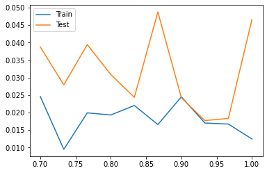

```python
# let's change learning rate to 0.7
# influence of subsample


x = np.linspace(0.7, 0.9999, 10)
ytrain = []
ytest = []

for i in x:
  bestModel = GradientBoostingRegressor(verbose = 1, criterion = 'friedman_mse',learning_rate= 0.7, max_depth= 5, max_features= 'sqrt', min_samples_leaf= 0.1, min_samples_split= 0.01, n_estimators= 9, subsample= i)
  bestPipeline = Pipeline(steps=[('preprocessor', preprocessor),
                              ('model', bestModel)
                             ])
  bestPipeline.fit(trainX, trainy.values.ravel())

  prediction = bestPipeline.predict(testX)
  ytest.append(rmse(testy.values.ravel(), prediction))
  prediction = bestPipeline.predict(trainX)
  ytrain.append(rmse(trainy.values.ravel(), prediction))

plt.plot(x, ytrain, label="Train")
plt.plot(x, ytest, label="Test")
plt.legend()
plt.show()
```

```
      Iter       Train Loss      OOB Improve   Remaining Time
         1  5082218388.3066   972482996.9770            0.02s
         2  3278425133.7839  2239011756.3212            0.02s
         3  2967733303.7421   160679365.9833            0.01s
         4  2685489672.6162   476488952.2974            0.01s
         5  2373914728.9547   164640361.1480            0.01s
         6  2579665576.1437    74809508.4024            0.01s
         7  2472689674.8040   115105616.5720            0.00s
         8  2342616424.7303   -52264015.5524            0.00s
         9  2255139723.0866   -81631664.0607            0.00s
      Iter       Train Loss      OOB Improve   Remaining Time
         1  5068276566.4526   865335136.3161            0.02s
         2  3018198192.8437  2028457778.3723            0.02s
         3  2462498395.8479   648665634.0353            0.01s
         4  2549515212.8310   150324114.3523            0.01s
```

[output cut: 55 more lines]

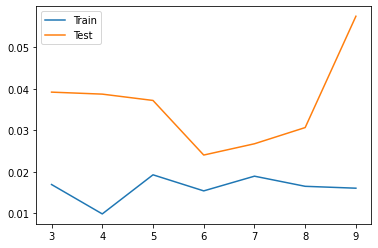

```python
# let's change subsample to 0.95
# influence of max_depth


x = [3, 4, 5, 6, 7, 8, 9]
ytrain = []
ytest = []

for i in x:
  bestModel = GradientBoostingRegressor(verbose = 1, criterion = 'friedman_mse',learning_rate= 0.7, max_depth= i, max_features= 'sqrt', min_samples_leaf= 0.1, min_samples_split= 0.01, n_estimators= 9, subsample= 0.95)
  bestPipeline = Pipeline(steps=[('preprocessor', preprocessor),
                              ('model', bestModel)
                             ])
  bestPipeline.fit(trainX, trainy.values.ravel())

  prediction = bestPipeline.predict(testX)
  ytest.append(rmse(testy.values.ravel(), prediction))
  prediction = bestPipeline.predict(trainX)
  ytrain.append(rmse(trainy.values.ravel(), prediction))

plt.plot(x, ytrain, label="Train")
plt.plot(x, ytest, label="Test")
plt.legend()
plt.show()
```

```python
#let's change max_depth to 6
bestModel = GradientBoostingRegressor(verbose = 1, criterion = 'friedman_mse',learning_rate= 0.7, max_depth= 6, max_features= 'sqrt', min_samples_leaf= 0.1, min_samples_split= 0.01, n_estimators= 9, subsample= 0.95)
bestPipeline = Pipeline(steps=[('preprocessor', preprocessor),
                              ('model', bestModel)
                             ])
bestPipeline.fit(trainX, trainy.values.ravel())

prediction = bestPipeline.predict(testX)

print ("rmse = ", rmse(testy.values.ravel(), prediction))
```

```
      Iter       Train Loss      OOB Improve   Remaining Time
         1  4133965522.2131  2537860135.3777            0.03s
         2  3852534423.8987    54278293.9914            0.02s
         3  2848758058.8744   611693340.3124            0.01s
         4  2662993271.2858   170242752.7012            0.01s
         5  2281324671.2516   290406095.8746            0.01s
         6  2506625246.9205    14466682.4009            0.01s
         7  2482455397.9548   -25134095.6783            0.00s
         8  2328706980.8041    83306363.0062            0.00s
         9  2299875936.4817    -3205525.3484            0.00s
rmse =  0.025544037640940244
```